# Estimación del ingreso laboral en Nuevo León mediante regresión robusta

## 1. Introducción

La distribución del ingreso laboral en México presenta una alta concentración de valores extremos, así como una marcada heterocedasticidad. Estas características dificultan el uso de modelos tradicionales como la regresión OLS, cuyos supuestos de homocedasticidad y normalidad no se cumplen en este contexto. Por ello, se adopta una regresión robusta como herramienta metodológica para estimar el ingreso laboral de manera más confiable.

Este estudio aplica una versión ajustada de la ecuación de Mincer, incorporando variables de escolaridad, experiencia laboral, sexo y región geográfica. La variable dependiente se transforma mediante el logaritmo natural para corregir la asimetría y modelar efectos porcentuales. Posteriormente, se realiza una exponenciación para ofrecer resultados comprensibles en términos monetarios.

## 2. Objetivo

Presentar estimaciones del ingreso mensual para jefes de familia en Nuevo León, segmentadas por sexo y región, utilizando un modelo robusto que reduce la influencia de observaciones atípicas y mejora la estabilidad de los coeficientes.

## 3. Justificación

El test de Breusch-Pagan confirma la presencia de heterocedasticidad en el modelo OLS, lo que refuerza la necesidad de aplicar técnicas robustas. La comparación entre modelos muestra que los coeficientes clave se estabilizan al utilizar regresión robusta, especialmente en el caso de variables regionales. Este enfoque es vital para informar políticas públicas basadas en evidencia.

## Ecuación de Mincer ajustada mediante un modelo de regresión robusta

Para reducir el impacto que tienen: los valores extremos de los ingresos mensuales de las personas (tanto altos como bajos), la distribución no normal de los errores y la heterocedastacidad estructural se introduce el modelo de Regresión Robusta, https://es.wikipedia.org/wiki/Regresi%C3%B3n_robusta, que permite reducir la influencia de las observaciones extremas, produce estimadores más estables cuando no podemos contar con homocedasticidad lo que nos permite tener un modelo más confiable en en el retorno estimado de la escolaridad y la experiencia cuando los datos pueden estar contaminados.

La fórmula estimada de la ecuación de Mincer es la siguiente:

$$\hat{lim} = \hat{\beta}_0 + \hat{\beta}_1
aniosestudio+ \hat{\beta}_2 aniosexperiencia+ \hat{\beta}_3
aniosexperiencia^2+ \hat{\beta}_4 Hombre +$$

$$\hat{\beta}_5 regionCITRICOLA+
\hat{\beta}_6 regionMETROPOLITANA + \hat{\beta}_7 regionNORTE +
\hat{\beta}_8 regionPERIFERICA + \hat{\varepsilon}$$

Dónde:  
lim : corresponde al logaritmo de los ingresos mensuales de los jefes de familia B0: es el intercepto  
anios_estudio: número de años cursados desde la primaria  
anios_experiencia: número de años en el trabajo a partir de que dejan de estudiar  
anios_experiencia_2: numero de años en el trabajo al cuadrado  
Hombre: variable dummy considerando 1 si es hombre, 0 si es mujer  
regionCITRICOLA: variable dummy categórica de personas que viven en la región citrícola  
regionMETROPOLITANA: variable dummy categórica de personas que viven en la región metropolitana  
regionNORTE: variable dummy categórica de personas que viven en la región norte  
regionPERIFERICA: variable dummy categórica de personas que viven en la región periférica  
Se consideró como base la región sur que presenta las condiciones marginación más bajo del estado de Nuevo León

### Detección de heterocedasticidad en el modelo OLS

Se analiza la posibilidad de heterocedasticidad en el modelo OLS estimado, el cual emplea la ecuación de Mincer para estimar el efecto de la educación, experiencia y otras variables sociodemográficas sobre el ingreso laboral.

Resultados del test de Breusch-Pagan para el modelo OLS

|  | Estadístico | Valor_BP | Grados_Libertad | Valor_p | Interpretación |
| --- | --- | --- | --- | --- | --- |
| BP | Breusch-Pagan | 389.32 | 8 | < 1e-04 | Rechaza H₀: Hay heterocedasticidad |

**Interpretación:**

Dado que el valor p de la prueba es menor a 0.05, se rechaza la hipótesis nula de homocedasticidad. Esto indica que los residuos del modelo no presentan varianza constante, y por tanto, las estimaciones OLS podrían estar sesgadas en sus errores estándar.

Recomendación metodológica /n

El modelo OLS presenta indicios de heterocedasticidad, lo cual puede afectar la precisión de los errores estándar y los intervalos de confianza.

## Aplicación de regresión robusta

Comparación de coeficientes entre modelo OLS y modelo robusto (RLM)

| Variable | Coef_OLS | Coef_Robusta | Diferencia |
| --- | --- | --- | --- |
| (Intercept) | 6.1071995 | 6.0803146 | -0.0268849 |
| anios_estudio | 0.1083629 | 0.1113873 | 0.0030243 |
| anios_experiencia | 0.0081730 | 0.0084592 | 0.0002862 |
| anios_experiencia_2 | -0.0000826 | -0.0000801 | 0.0000025 |
| Hombre | 0.2094426 | 0.2122563 | 0.0028137 |
| regionCITRICOLA | 0.3140016 | 0.3042785 | -0.0097230 |
| regionMETROPOLITANA | 0.4700066 | 0.4460177 | -0.0239889 |
| regionNORTE | 0.6431852 | 0.6497144 | 0.0065292 |
| regionPERIFERICA | 0.3458694 | 0.3293552 | -0.0165142 |

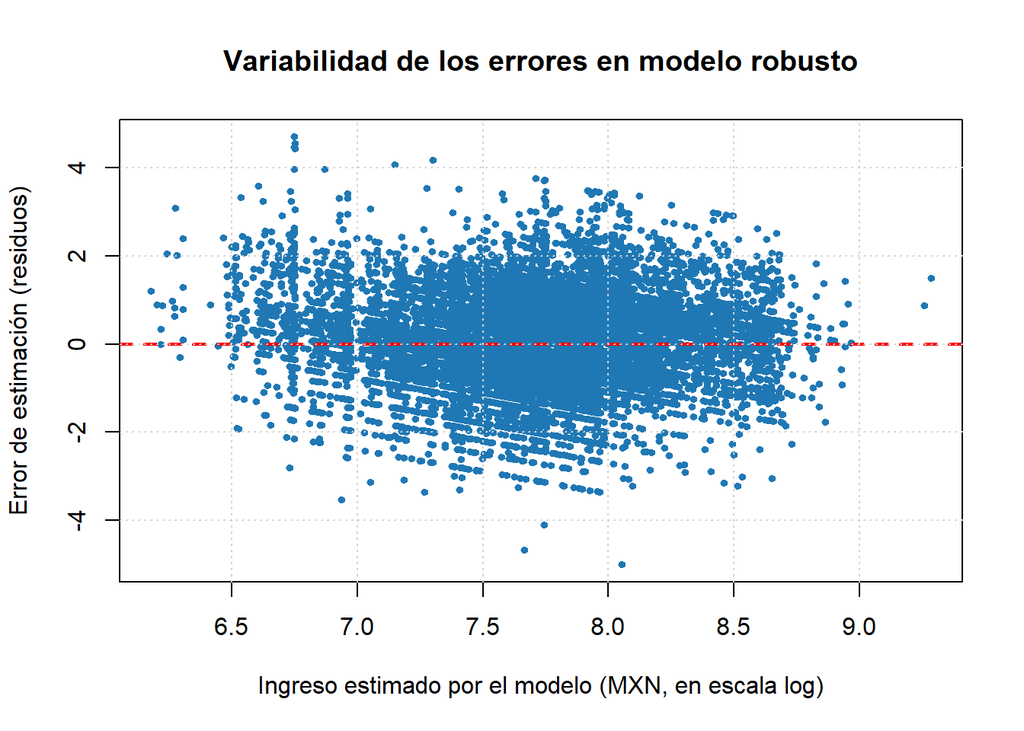

🧾 Texto explicativo del gráfico de residuos

Este gráfico muestra qué tan acertadas son las estimaciones del modelo robusto al predecir el ingreso mensual. Cada punto representa una persona. Cuanto más cerca están del centro (línea roja), menor es el error.

Gracias al modelo robusto, los errores extremos se reducen y se concentran en torno al promedio, lo que da lugar a estimaciones más estables y confiables. Esto es especialmente valioso en contextos con gran desigualdad, como el ingreso laboral, donde los modelos tradicionales pueden ser engañosos. La regresión robusta permite estimar los coeficientes de manera más confiable ante la presencia de valores atípicos y varianza no constante.

Las variables clave como escolaridad, experiencia y género muestran alta estabilidad entre ambos modelos, lo cual valida sus efectos estructurales.

Las diferencias observadas en variables regionales sugieren que el modelo robusto ajusta mejor los efectos territoriales al reducir el peso de ingresos extremos.

En consecuencia, se recomienda utilizar el modelo robusto como referencia principal en la interpretación de efectos sobre el ingreso laboral.

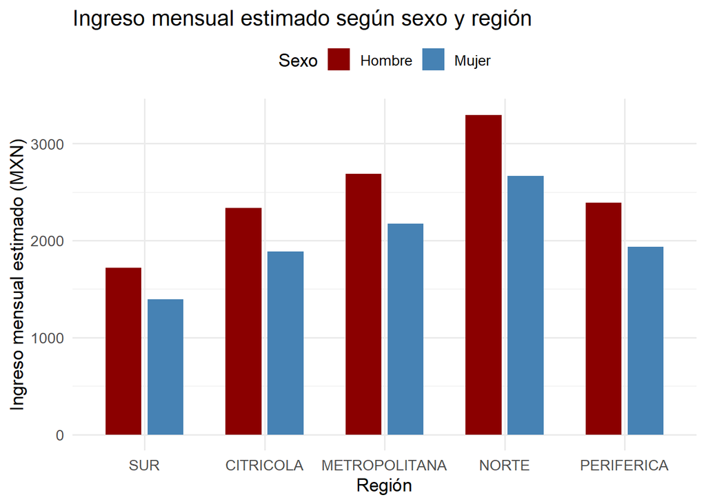

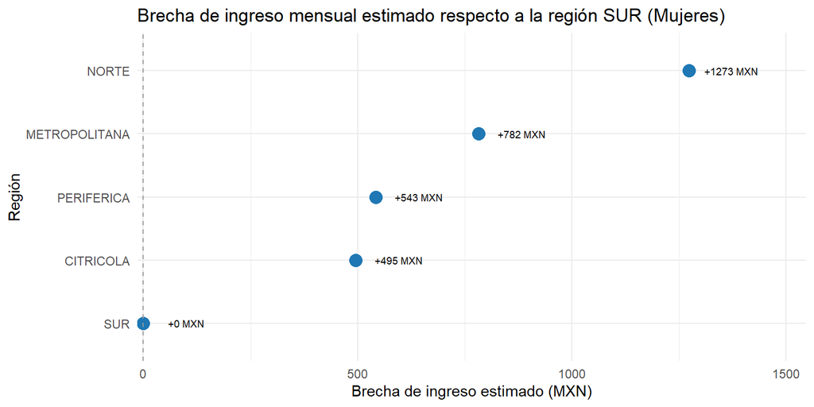

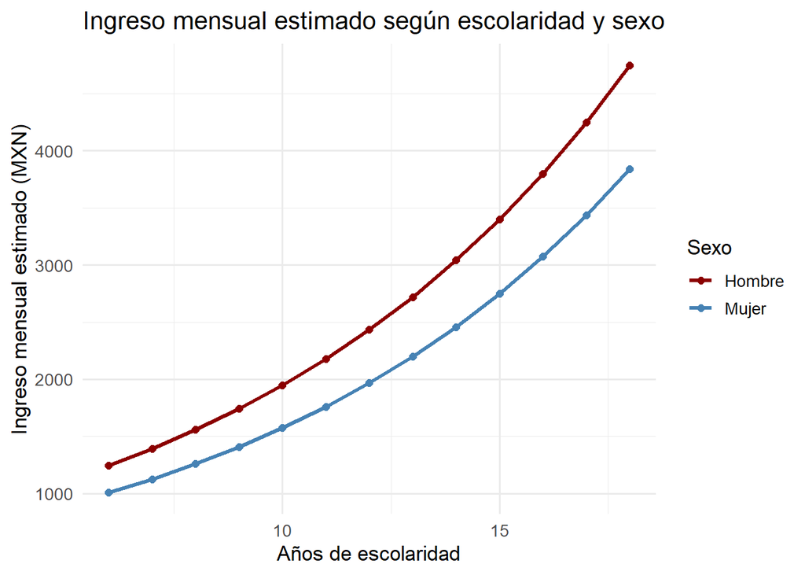

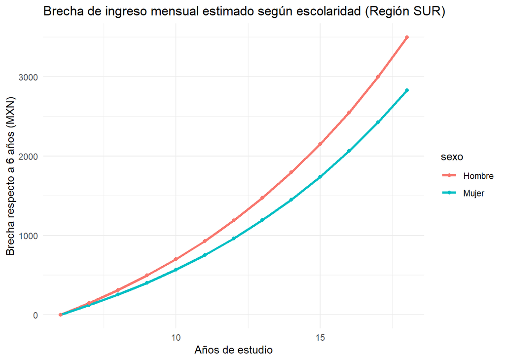

## Estabilidad de coeficientes principales

- Las variables estructurales del modelo —escolaridad, experiencia, y género— muestran consistencia notable entre las estimaciones OLS y robustas. Esto respalda la confiabilidad del modelo para estimar retornos a la educación y participación laboral.

## Ajustes en efectos regionales

- Las diferencias en los coeficientes regionales sugieren que el modelo robusto atenúa la influencia de observaciones extremas, ofreciendo estimaciones más equilibradas. Especialmente en zonas como la Metropolitana, donde los ingresos altos tienden a distorsionar el modelo tradicional.
- Para una mujer jefa de familia en la región SUR, aumentar la escolaridad de 6 a 18 años implica una diferencia promedio de $2,830 pesos mensuales. En el caso de los hombres, esta diferencia alcanza los $3,499 pesos mensuales.

## Reducción de errores extremos

- El análisis de residuos revela menor dispersión y concentración en torno a la media, lo que valida la robustez del modelo ante datos con alta desigualdad. Esta característica es esencial en contextos de política pública donde las decisiones se basan en estimaciones estables y representativas.

[output not shown]